# Intervals for Predictions Assignment

Last Updated: September 30, 2024 08:13:12

Priscilla Erickson from Kenyon College collected data on a stratified random sample of 116 Savannah sparrows at Kent Island. The weight (in grams) and wing length (in mm) were obtained for birds from nests that were reduced, controlled, or enlarged.

### 1. What is the slope of the least squares regression line for predicting sparrow weight from wing length?

```r
coef(lm(Weight ~ WingLength))[2]
```

```
## WingLength
##   0.467404
```

### 2. Based on the regression output, what is the intercept of the least squares regression line for predicting sparrow weight from wing length?

```r
coef(lm(Weight ~ WingLength))[1]
```

```
## (Intercept)
##     1.36549
```

### 3. Based on the regression output, what is the size of the typical error when predicting weight from wing length?

```r
summary(lm(Weight ~ WingLength))
```

```
##
## Call:
## lm(formula = Weight ~ WingLength)
##
## Residuals:
##     Min      1Q  Median      3Q     Max
## -3.5440 -0.9935  0.0809  1.0559  3.4168
##
## Coefficients:
##             Estimate Std. Error t value Pr(>|t|)
## (Intercept)  1.36549    0.95731   1.426    0.156
## WingLength   0.46740    0.03472  13.463   <2e-16 ***
## ---
## Signif. codes:  0 '***' 0.001 '**' 0.01 '*' 0.05 '.' 0.1 ' ' 1
##
## Residual standard error: 1.4 on 114 degrees of freedom
## Multiple R-squared:  0.6139, Adjusted R-squared:  0.6105
## F-statistic: 181.3 on 1 and 114 DF,  p-value: < 2.2e-16
```

### 4. What are the degrees of freedom associated with the standard regression error when predicting weight from wing length for these sparrows?

```r
summary(lm(Weight ~ WingLength))$df[2]
```

```
## [1] 114
```

### 5. Construct and interpret the following plots for the residuals of this model.

In each case, discusswhat the plot tells you about potential problems (if any) with the regression conditions.

#### 5a. Histogram of the residuals.

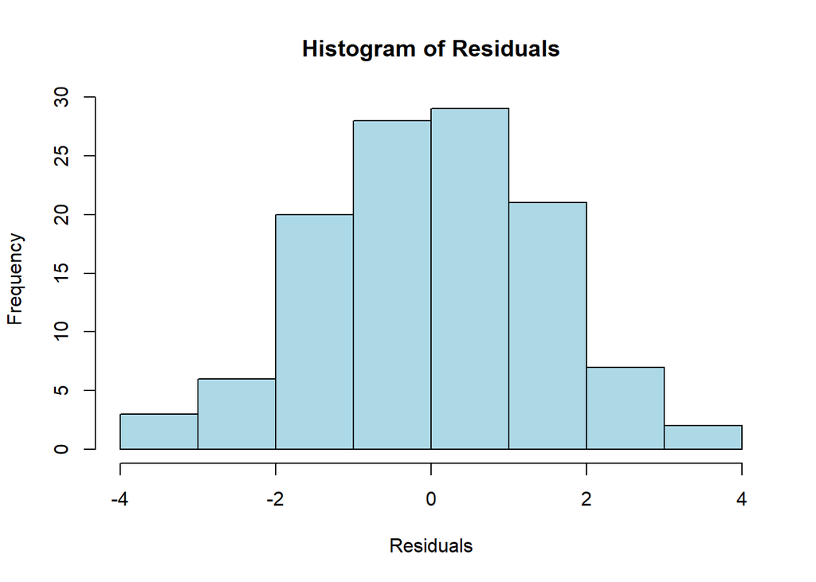

```r
hist(residuals(lm(Weight ~ WingLength)), main = "Histogram of Residuals", xlab = "Residuals", ylab = "Frequency", col = "lightblue")
```